# Habitat Chapter JAGS Detection Model 2

Anna Kurtin

5/31/2024

## Data Reading and Formatting

I’m going to read in the data, look at it’s distribution, and format it for use in JAGS. As part of this formatting, I will be centering and scaling the data, so that each covariate has a mean of 0 and standard deviation of 1. This means that the covariates are interpretable compared to one another and allows us to pull from a normal distribution for our priors and initial values.

Format detection data, which has been separated into two-week survey periods. This data represents a 1 if any BBCU vocalizations were confirmed at any point within the site within the two week survey period.

*Scripts: ./R_Scripts/3_Data_Wrangling_Tidying/Detection_History/CreateDetectionHistoryPeriods_camtrapR.R & /Create_Datasheets_forDetectionHistory.R*

```r
# y data: read in a dataframe that has a row for every point and a column for every detection period
detections_orig <- read.csv("C:/Users/annak/OneDrive/Documents/UM/Research/Coding_Workspace/Cuckoo-Research/Data/Detection_History/2023_All_ARUs/Outputs/DetectionHist_CamTrapR/bbcu__detection_history__with_effort__14_days_per_occasion__2024-04-29.csv") %>% clean_names
survey_startdate <- colnames(detections_orig)
# Make a copy of the data
detections <- detections_orig
colnames(detections) <- c("site_session","det_survey1","det_survey2","det_survey3","det_survey4","det_survey5","det_survey6")
# Split apart the detections into site and point
detections <- detections %>% separate(site_session, into = c("site_id","session_name"), sep = "__")
```

Format the date covariate. This is a survey-level covariate that represents the start date of each survey period. We can see from the distribution that this follows a uniform distribution.

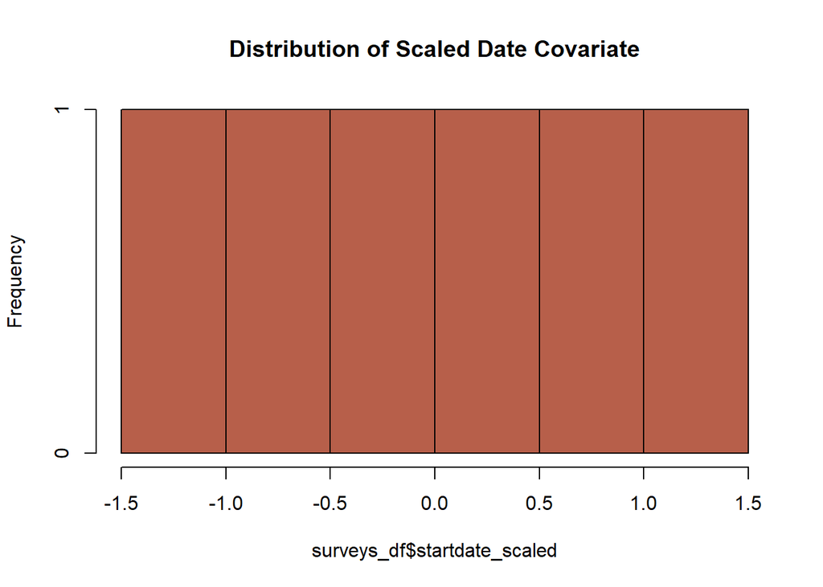

```r
# Create the values for date
# Remove the value with just "x", remove "x" from the rest, reformat dates
surveys_cleaned <- survey_startdate[-1] %>%
  gsub("^x", "", .) %>%            # Remove the leading "x"
  gsub("_", "-", .)                # Replace underscores with hyphens
# then convert it into a dataframe
# Convert to a dataframe
surveys_df <- data.frame(survey_period = surveys_cleaned)
# Split the survey_period into start_date and end_date
surveys_df <- surveys_df %>%
  separate(survey_period, into = c("start_date", "end_date"),sep = "(?<=\\d{4}-\\d{2}-\\d{2})-")
# Convert it to date
surveys_df <- surveys_df %>% mutate(start_date = as.Date(start_date, format = "%Y-%m-%d"),
                                    end_date = as.Date(end_date, format = "%Y-%m-%d"))
# Convert to Julian Date
surveys_df <- surveys_df %>% mutate(start_julian = yday(start_date),
                                        end_julian = yday(end_date))
# Scale the start date
surveys_df$startdate_scaled <- scale(surveys_df$start_julian, center = TRUE)[,1]
# Pivot wider then rename the columns
start_dates <- surveys_df$startdate_scaled
# Plot the distribution
hist(surveys_df$startdate_scaled, col = cuckoo_palette[1], main = "Distribution of Scaled Date Covariate")
```

*Script: ./R_Scripts/3_Data_Wrangling_Tidying/Detection_Covariates/Combine_Veg_Survey_Plant_Data.R*

```r
# Site-level covariates
# Read in vegetation density for each site
vegdense <- read.csv("C:/Users/annak/OneDrive/Documents/UM/Research/Coding_Workspace/Cuckoo-Research/Data/Habitat_Model_Covariates/Detection_Covariates/ShrubTreeDensityComposite_2023_ARUPoints.csv")
vegdense <- vegdense %>% create_site_col()
# take the average of this across the site
vegdense_avg <- vegdense %>% group_by(site_id,sampling_design) %>% summarize(veg_density_avg = round(mean(composite_dense,na.rm = TRUE),2))
```

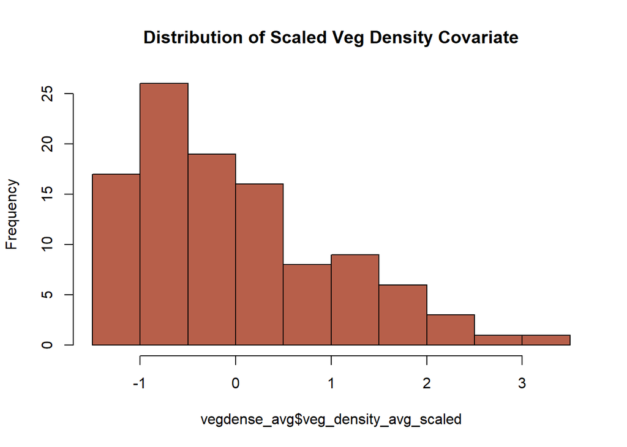

```r
vegdense_avg <- as.data.frame(vegdense_avg)
# Scale this covariate
vegdense_avg$veg_density_avg_scaled <- scale(vegdense_avg$veg_density_avg)[,1]
vegdense_fin <- vegdense_avg %>% select(site_id,veg_density_avg_scaled)
# Look at the distribution
hist(vegdense_avg$veg_density_avg_scaled, col = cuckoo_palette[1], main = "Distribution of Scaled Veg Density Covariate")
```

Format the background noise covariate. This covariate represents the average background noise in decibels during each survey period at the site. To create this covariate, I calculated the average decibels within the bandpass filter used by the cuckoo classifier (200-3500 Hz) for each audio file. Then, I assigned each audio file to a survey period, based on the same date intervals used for detection history. I grouped by site ID and survey period, then calculated the average decibel value. This covariate follows a normal distribution.

*Script: ./R_Scripts/3_Data_Wrangling_Tidying/Detection_Covariates/Create_Survey_Level_BackgrounddB.R*

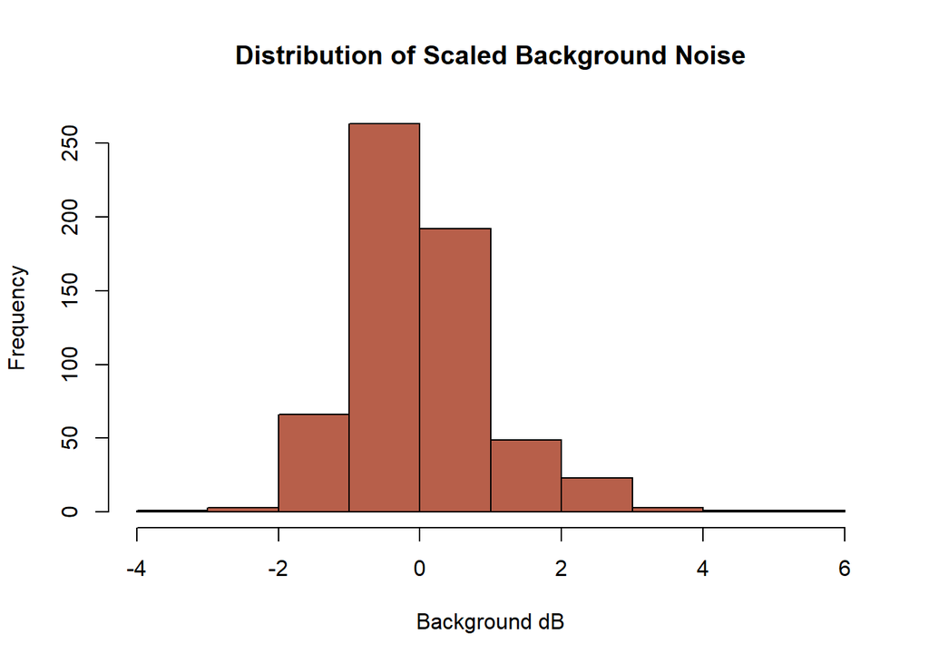

```r
# background noise
background_db <- read.csv("C:/Users/annak/OneDrive/Documents/UM/Research/Coding_Workspace/Cuckoo-Research/Data/Habitat_Model_Covariates/Detection_Covariates/BackgroundNoiseBandpass_2023_ARUPoints.csv")
colnames(background_db) <- c("site_id","backdb_survey1","backdb_survey2","backdb_survey3","backdb_survey4","backdb_survey5","backdb_survey6")
# Pivot longer for scaling
db_long <- background_db %>% pivot_longer(cols = c(backdb_survey1,backdb_survey2,backdb_survey3,backdb_survey4,backdb_survey5,backdb_survey6), names_to = "survey_period",values_to = "db" )
# Checking why they have [,1] after all the names when I use scale
# test <- scale(db_long$db, center = TRUE, scale = TRUE)
# test[,1]
# test[,2] # Why can't I query the other items of the list?
# test[1,]
# test
# Looks like scale() returns a list of lists where the first value is the actual scaled data and the second value is the quantity to which the data was centered and sclaed to
# Scale it
db_long$db_scaled <- scale(db_long$db, center = TRUE)[,1]
# Check the distribution
hist(db_long$db_scaled, xlab = "Background dB", main = "Distribution of Scaled Background Noise", col = cuckoo_palette[1])
```

```r
# Pivot wider for use in model
db_fin <- db_long %>% select(-db) %>% pivot_wider(names_from = survey_period, values_from = db_scaled)
```

Format the effort data. This data was created along with the two-week detection periods. I created an effort covariate by extracting the size of each audio file and writing that to a datasheet. Then, I counted a unit as active only if it had an audio file from a given day and if that audio file met the correct size threshold. I screened out audio files that were the proper size but had issues within the recording so that you could not detect sounds in the range of cuckoo vocalizations (200-3500 Hz). With this record of audio files recorded per day for each recording unit, I then used package camtrapR to calculate effort to represent the hours of audio recorded per day/percentage of the 2 hours per day successfully recorded. In camtrapR, I grouped recording units by site and summed up the effort per site across each survey period.

*Scripts: ./R_Scripts/3_Data_Wrangling_Tidying/Detection_History/CreateDetectionHistoryPeriods_camtrapR.R & /Create_Datasheets_forDetectionHistory.R*

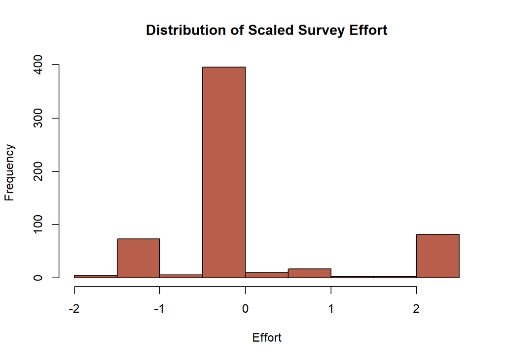

```r
# Read in detection and effort data
effort <- read.csv("C:/Users/annak/OneDrive/Documents/UM/Research/Coding_Workspace/Cuckoo-Research/Data/Detection_History/2023_All_ARUs/Outputs/DetectionHist_CamTrapR/bbcu__effort__not_scaled_14_days_per_occasion__2024-04-29.csv") %>% clean_names
#survey_periods <- colnames(effort)
# Rename columns
colnames(effort) <- c("site_session","effort_survey1","effort_survey2","effort_survey3","effort_survey4","effort_survey5","effort_survey6")
# Clean up the columns
effort <- effort %>% separate(site_session, into = c("site_id","session_name"), sep = "__") %>% select(-session_name)
# Pivot longer for scaling
effort_long <- effort %>% pivot_longer(cols = c(effort_survey1,effort_survey2,effort_survey3,effort_survey4,effort_survey5,effort_survey6), names_to = "survey_period",values_to = "effort" )
# Sclae it
effort_long$effort_scaled <- scale(effort_long$effort, center = TRUE)[,1]
# Look at the distribution
hist(effort_long$effort_scaled, xlab = "Effort", main = "Distribution of Scaled Survey Effort", col = cuckoo_palette[1])
```

```r
# Pivot wider for use in model
# Pivot wider for use in model
effort_fin <- effort_long %>% select(-effort) %>% pivot_wider(names_from = survey_period, values_from = effort_scaled)
```

After all of my covariates were formatted and scaled, I combined them into one dataframe to use in my model.

```r
# Combine them
full_dat <- left_join(detections,db_fin, by = "site_id")
full_dat <- left_join(full_dat,vegdense_fin, by = "site_id")
full_dat <- left_join(full_dat, effort_fin, by = "site_id")
full_dat <- full_dat %>% mutate(start_date_s1 = start_dates[1],
                     start_date_s2 = start_dates[2],
                     start_date_s3 = start_dates[3],
                     start_date_s4 = start_dates[4],
                     start_date_s5 = start_dates[5],
                     start_date_s6 = start_dates[6])
# Remove unwanted column
full_dat <- full_dat %>% select(-c(session_name))
# Save for future use
#saveRDS(full_dat, file ="./Data/Habitat_Model_Covariates/Full_DetectionDataSCALED_JAGSModels_HabChap.Rdata")
```

Let’s load in the data that I just formatted and scaled.

```r
full_dat <- readRDS(file ="C:/Users/annak/OneDrive/Documents/UM/Research/Coding_Workspace/Cuckoo-Research/Data/Habitat_Model_Covariates/Full_DetectionDataSCALED_JAGSModels_HabChap.Rdata")
```

## New and Improved (Fixed) Model

Next, I am going to run a JAGS model that I’ve specified for a single season, single species occupancy model. The actual model file includes the likelihood statement and the prior distributions for each covariate.

With Thomas R.’s input, I changed my priors to reflect the fact that these inform the probability distribution for the covariate effects, not the values of the covariates themselves and corrected the priors for the intercept of occupancy and detection probability.

Note also that this model fills in values drawn from the prior distribution for NAs in the data. It does this for missing detection data as well as missing covariates.

```r
# b1/cov1: date
# b2/cov2: veg density
# b3/cov3: background noise
# b4/cov4: effort

# Create the jags_model
cat("
  model{
    # Loop through each sampling unit
    for(i in 1:n_unit){
      Z[i] ~ dbern(psi[i])  # Presence or absence drawn from a bernoulli distribution with occupancy probability psi
      logit(psi[i]) <- a0

      cov2[i] ~ dnorm(0, 1) # Assuming normal distribution for missing covariates

      for(j in 1:n_rep){
        cov1[i,j] ~ dnorm(0, 1) # Assuming normal distribution for missing covariates
        cov3[i,j] ~ dnorm(0, 1) # Assuming normal distribution for missing covariates
        cov4[i,j] ~ dnorm(0, 1) # Assuming normal distribution for missing covariates

        det_data[i,j] ~  dbern(Z[i]*theta[i,j])  # Create detection data drawn from a bernoulli distribution incorporating the true presence (Z) with probability of detection theta
        logit(theta[i,j]) <- b0 + b1*cov1[i,j] + b2*cov2[i] + b3*cov3[i,j] + b4*cov4[i,j]

      }
    }

    # Priors
    a0 ~ dlogis(0, 1)
    b0 ~ dlogis(0, 1)
    b1 ~ dnorm(0, 1)
    b2 ~ dnorm(0, 1)
    b3 ~ dnorm(0, 1)
    b4 ~ dnorm(0, 1)
  }
  ", file = "./R_Scripts/2_Analyses/Habitat_Chapter/Detection_Submodel/Model_Structure_Files/JAGS_HabDetMod2.txt")
```

I also specify which parts of my data correspond to which covariates or detections and specify the distribution from which to pull the initial values. Note also that I created a separate value `z_dat` to tell the model which sites had true presence based on our detection data. If you don’t specify this value, the model may simulate that a cuckoo was absent at a site where you had a detection, which will break the model.

```r
# Pull out the detections so that you have n_unit and n_site
detections_only <- full_dat[,2:7]

# Have to specify the z data for a true presence if there was a 1 at any time
z_dat <- rowSums(detections_only, na.rm = T)
z_dat[z_dat > 1] <- 1
z_dat[z_dat == 0] <- NA

# Create a list of data for JAGS
jags_data <- list(
  # True presence at sites with confirmed presences
  Z = z_dat,
  # Detection/nondetection data
  det_data = detections_only,
  # Date
  cov1 = full_dat[,21:26],
  # Veg Density - site level
  cov2 = full_dat[,14],
  # Background noise
  cov3 = full_dat[,8:13],
  # Effort
  cov4 = full_dat[,15:20],
  n_unit = nrow(detections_only),
  n_rep = ncol(detections_only)
)

# Set initial values (optional)
init_func <- function(){
  list(
    a0 = rnorm(1, 0, 1),
    b0 = rnorm(1, 0, 1),
    b1 = rnorm(1, 0, 1),
    b2 = rnorm(1, 0, 1),
    b3 = rnorm(1, 0, 1),
    b4 = rnorm(1, 0, 1)
  )
}
```

Next, I establish the parameters for running the model itself. I specify the number of chains, which is the number of times that JAGS will create independent posterior distributions. The use of multiple chains is to ensure that they arrive to the same conclusion - they are “evenly mixed” as we will see in the traceplots. Next, I specify the total number of iterations. This is the number of times the MCMC sampler will run and draw new posterior values. Next, I specify the burnin period, which is the number of iterations JAGS will “throw out” before keeping the posterior draws in the chain. This is because we randomize our starting/initial values for each covariate, so if one of these initial values is very far off, the MCMC sampler will have some time to get it into a more normal range before we actually start monitoring the chains. Finally, I specify the number of thinning. This means that the MCMC sampler will keep out every other value it draws from the posterior distribution. Thinning the chains in this way reduces the amount of correlation between values in the posterior distribution and increases their independence.

```r
# Run JAGS model
habdet_m2 <- jags(data = jags_data,
                 model.file = "./R_Scripts/2_Analyses/Habitat_Chapter/Detection_Submodel/Model_Structure_Files/JAGS_HabDetMod2.txt",
                 parameters.to.save = c("a0", "b0", "b1", "b2", "b3", "b4"),
                 n.iter = 20000,
                 n.burnin = 4000,
                 n.chains = 3,
                 n.thin = 2,
                 parallel = TRUE,
                 inits = init_func)
saveRDS(habdet_m2, file = "./R_Scripts/2_Analyses/Habitat_Chapter/Detection_Submodel/Models_Ran_Outputs/Actual_Data/JAGS_Global_Detection_Model.Rdata")
```

## Evaluate Model Outputs

Once I’ve run the model, I’m going to take a look at the output to evaluate whether the model converged.

```r
# Read in the model that we saved after running the above code
habdet_m2 <- readRDS("C:/Users/annak/OneDrive/Documents/UM/Research/Coding_Workspace/Cuckoo-Research/R_Scripts/2_Analyses/Habitat_Chapter/Detection_Submodel/Models_Ran_Outputs/Actual_Data/JAGS_Global_Detection_Model.Rdata")

# Evaluating convergence
print(habdet_m2)
```

```
## JAGS output for model './R_Scripts/2_Analyses/Habitat_Chapter/Detection_Submodel/Model_Structure_Files/JAGS_HabDetMod2.txt', generated by jagsUI.
## Estimates based on 3 chains of 20000 iterations,
## adaptation = 100 iterations (sufficient),
## burn-in = 4000 iterations and thin rate = 2,
## yielding 24000 total samples from the joint posterior.
## MCMC ran in parallel for 1.511 minutes at time 2024-05-31 14:13:45.312435.
##
##              mean    sd     2.5%      50%    97.5% overlap0     f Rhat n.eff
## a0         -1.294 0.263   -1.821   -1.290   -0.783    FALSE 1.000    1 24000
## b0         -0.877 0.260   -1.405   -0.872   -0.385    FALSE 1.000    1 20054
## b1         -0.930 0.255   -1.450   -0.925   -0.447    FALSE 1.000    1 24000
## b2          0.061 0.214   -0.356    0.061    0.482     TRUE 0.610    1 14139
## b3         -0.291 0.225   -0.739   -0.289    0.143     TRUE 0.903    1 19414
## b4          0.232 0.206   -0.173    0.232    0.632     TRUE 0.872    1 24000
## deviance 5616.155 9.613 5598.521 5615.815 5635.954    FALSE 1.000    1 24000
##
## Successful convergence based on Rhat values (all < 1.1).
## Rhat is the potential scale reduction factor (at convergence, Rhat=1).
## For each parameter, n.eff is a crude measure of effective sample size.
##
## overlap0 checks if 0 falls in the parameter's 95% credible interval.
## f is the proportion of the posterior with the same sign as the mean;
## i.e., our confidence that the parameter is positive or negative.
##
## DIC info: (pD = var(deviance)/2)
## pD = 46.2 and DIC = 5662.364
## DIC is an estimate of expected predictive error (lower is better).
```

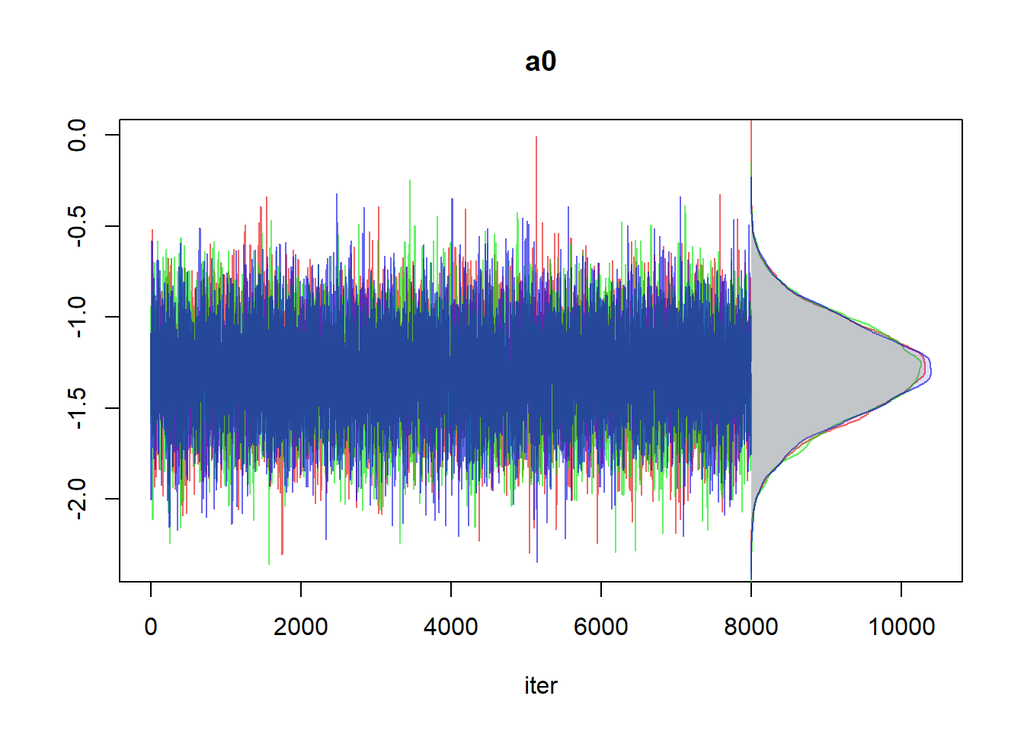

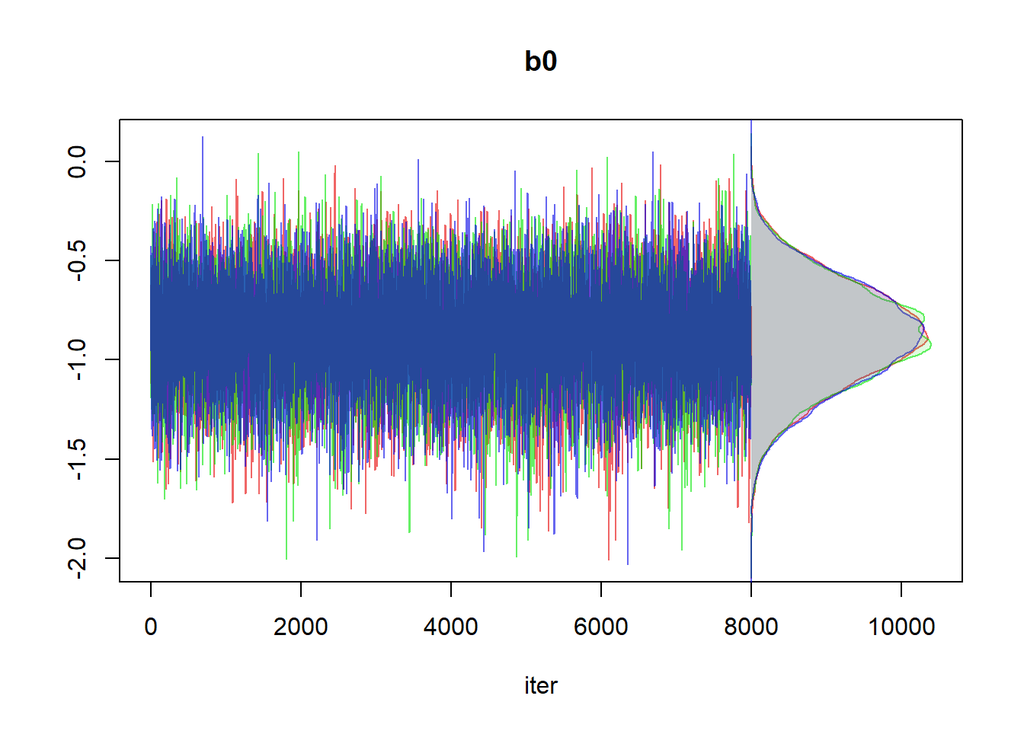

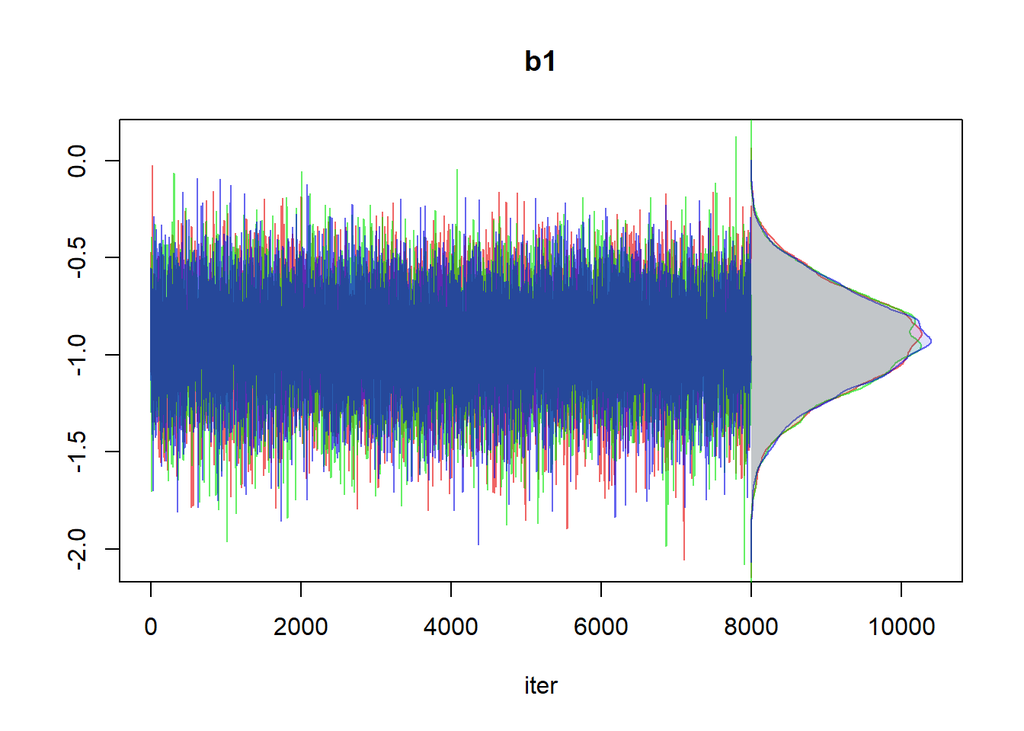

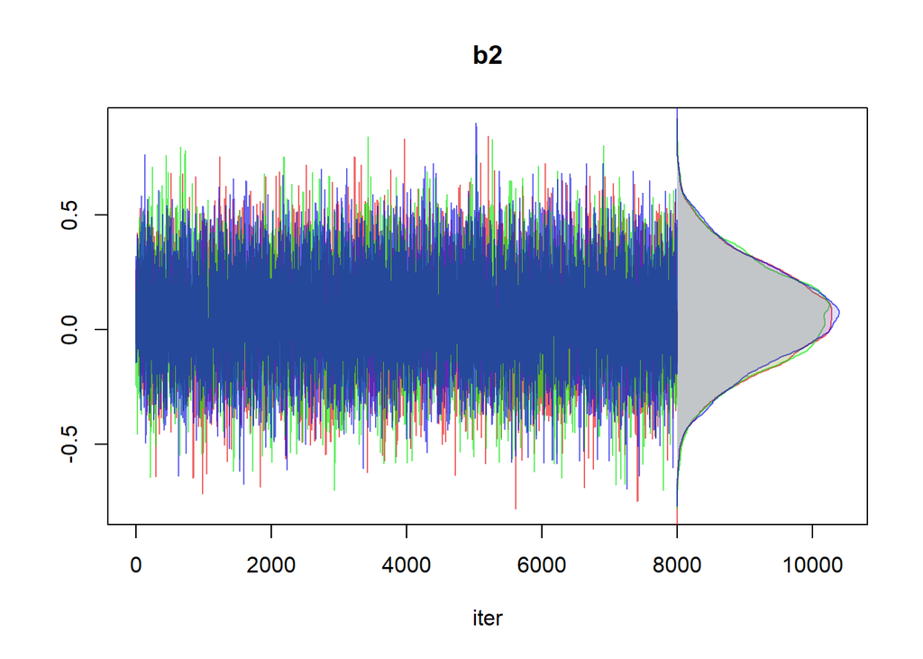

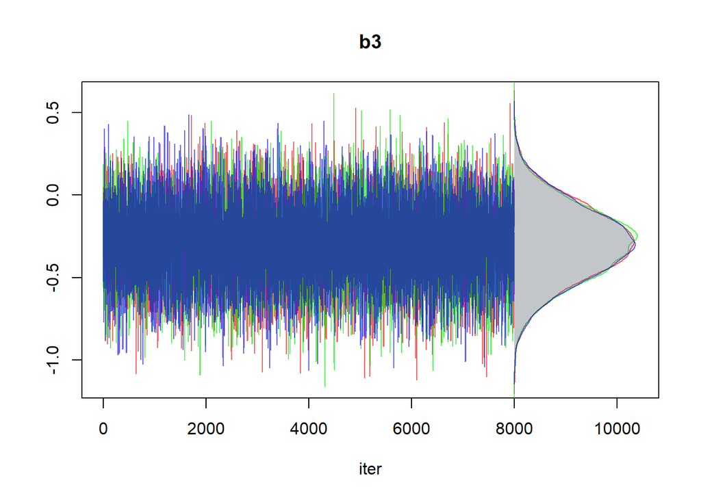

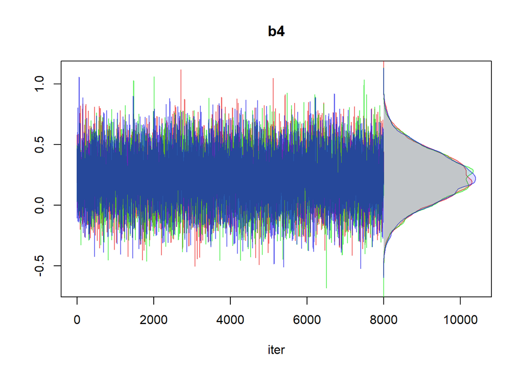

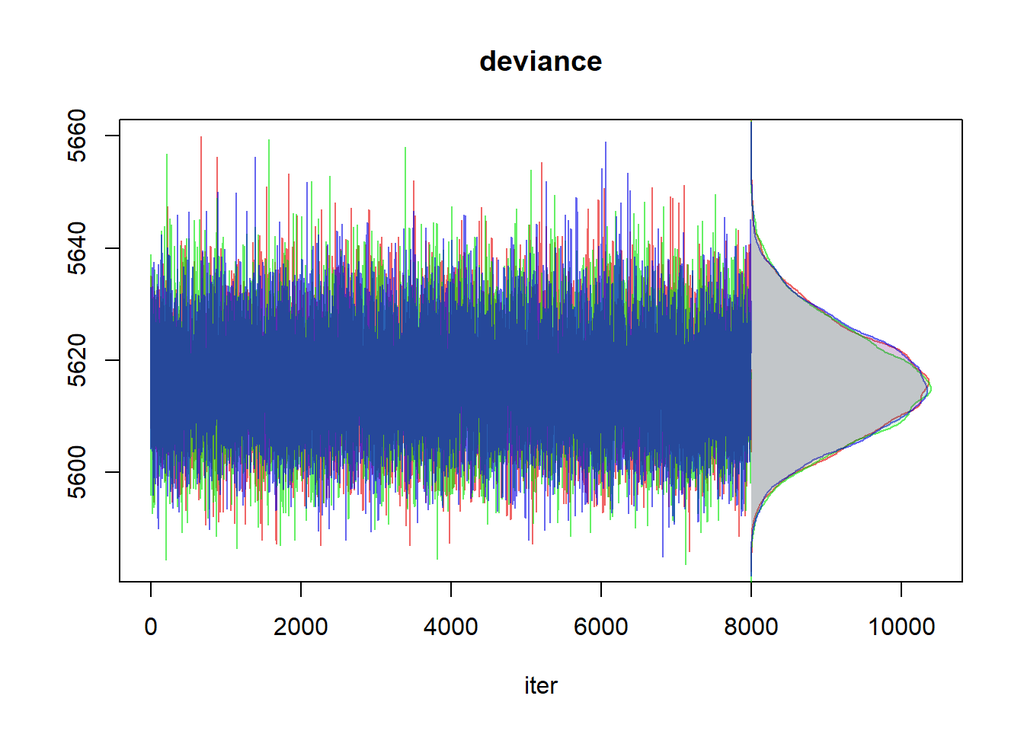

```r
tracedens_jags(habdet_m2)
```

Each chain looks evenly “mixed” with the others, meaning that there is high degrees of overlap. We also see this in our scale reduction factor (Rhat), which is close to 1 for all variables. The effective sample size also looks good (n_eff > 100 * n_chains), meaning that we have appropriately independent samples in our posterior distribution.

When I was running into issues with some covariates not converging, it was because I didn’t have my variables scaled. Therefore I was getting weird values when I plotted the posterior distributions for one covariate against the other, specifically when I was plotting date against background decibels. These plots were looking like a linear “track”, which indicated that the strongly negative unscaled values for b3 (background decibels) and strongly positive unscaled values for Julian date were pulling around the estimate too much. Now that I’ve fixed the data to be scaled, we can see that there is no correlation between the effects of the two covariates, which is what we want.

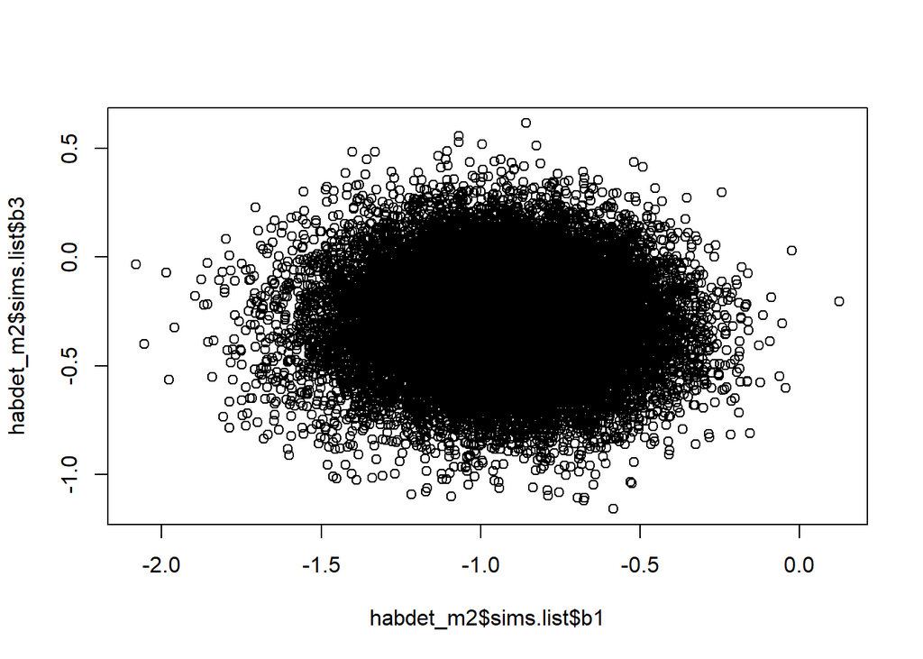

```r
#Plot posterior for b1 against posterior for b3 and intercept - if it looks like a "track", the covariates are pulling on each other too much
#plot(habdet_m2$sims.list$b0 ~ habdet_m2$sims.list$b3)
#plot(habdet_m2$sims.list$b0 ~ habdet_m2$sims.list$b1)
plot(habdet_m2$sims.list$b3 ~ habdet_m2$sims.list$b1)
```

When we looked at our summary, we saw that the only covariate whose effect didn’t overlap zero (is “significant” in Bayesian terms) was date. However, when we look more closely at the other covariates, we see that the f statistics (percentage of the samples from the posterior distribution that are on the same side of zero as the mean) for b3 (background noise) and b4 (effort) are fairly high. Let’s visualize these distributions to evaluate whether they are also having a substantial enough effect on detection to warrant keeping them in the model.

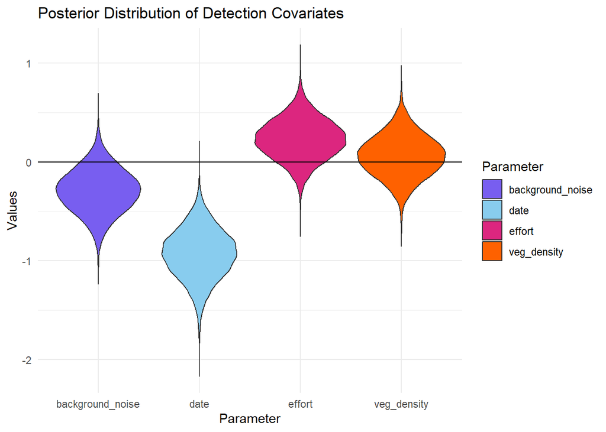

```r
# Plot posterior distribution
chains_m2 <- jags_df(habdet_m2)
# Select the chains for our covariates of interest
chains_viol <- chains_m2 %>% select(b1,b2,b3,b4)
# Rename them to be more interpretable
colnames(chains_viol) <- c("date","veg_density","background_noise","effort")
# Pivot this longer so that we can visualize it
chains_viol_long <- chains_viol %>% pivot_longer(cols = c("date","veg_density","background_noise","effort"),names_to = "Parameter", values_to = "Values")

# Create the violin plot
ggplot() +
  geom_violin(data=chains_viol_long, aes(x = Parameter, y = Values,fill = Parameter),trim = FALSE) +
  labs(title = "Posterior Distribution of Detection Covariates") +
  scale_fill_manual(values = c("date"=palette_5[1], "background_noise"=palette_5[2], "effort" = palette_5[3], "veg_density" = palette_5[4])) +
  geom_hline(yintercept = 0, linetype = "solid", color = "black") +
  theme_minimal()
```

From this plot, we can see that background noise, effort, and vegetation density overlap zero, but it background noise and effort overlap zero less than vegetation density. Let’s zero in on these covariates and also take a look at the distribution for date.

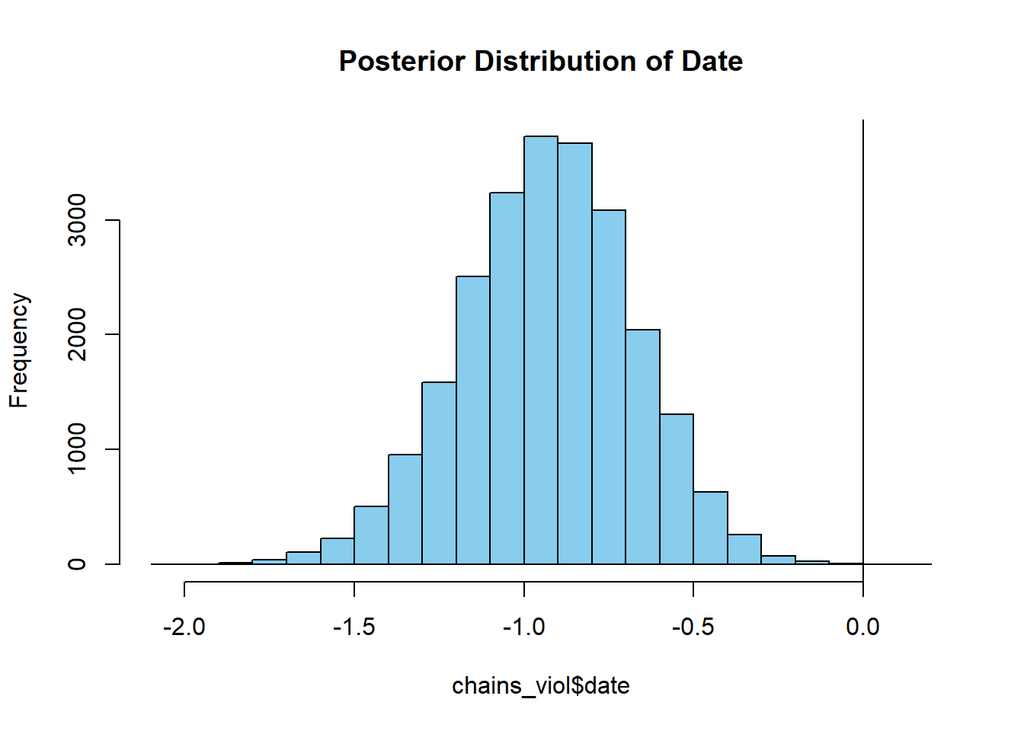

```r
hist(chains_viol$date, col = palette_5[1], main = "Posterior Distribution of Date")
abline(v = 0, col = "black")
```

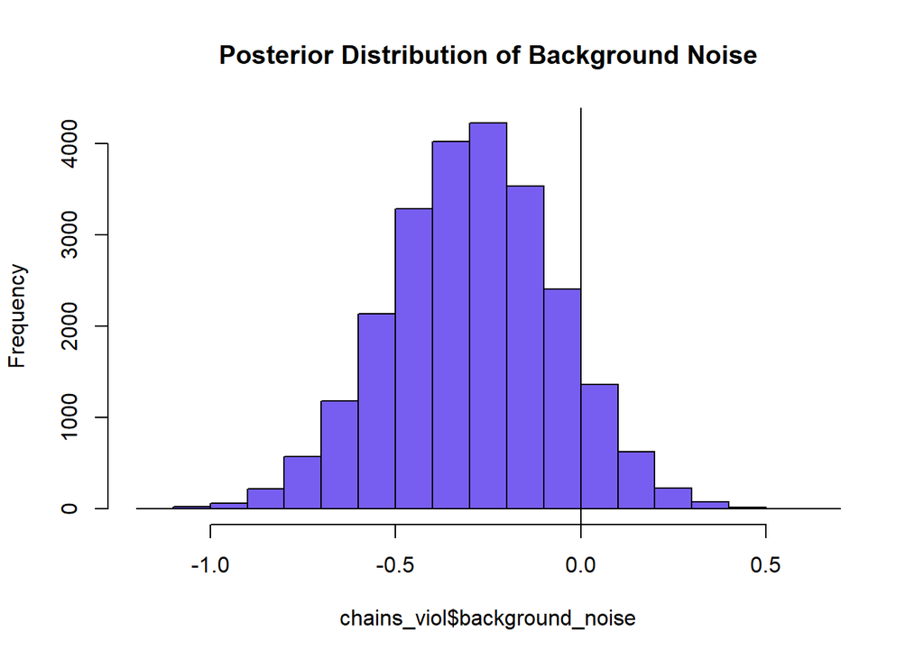

```r
hist(chains_viol$background_noise, col = palette_5[2], main = "Posterior Distribution of Background Noise")
abline(v = 0, col = "black")
```

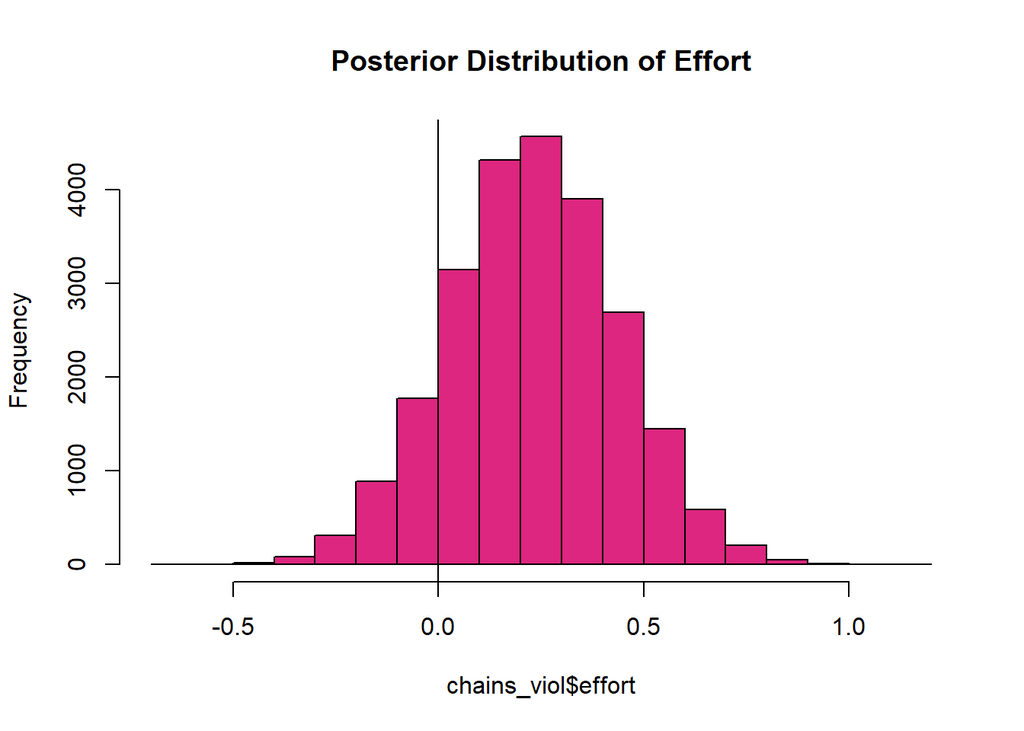

```r
hist(chains_viol$effort, col = palette_5[3], main = "Posterior Distribution of Effort")
abline(v = 0, col = "black")
```

## Quadratic effect for date

```r
# b1/cov1: date
# b2/cov2: veg density
# b3/cov3: background noise
# b4/cov4: effort

# Create the jags_model
cat("
  model{
    # Loop through each sampling unit
    for(i in 1:n_unit){
      Z[i] ~ dbern(psi[i])  # Presence or absence drawn from a bernoulli distribution with occupancy probability psi
      logit(psi[i]) <- a0

      cov2[i] ~ dnorm(0, 1) # Assuming normal distribution for missing covariates

      for(j in 1:n_rep){
        cov1[i,j] ~ dnorm(0, 1) # Assuming normal distribution for missing covariates
        cov3[i,j] ~ dnorm(0, 1) # Assuming normal distribution for missing covariates
        cov4[i,j] ~ dnorm(0, 1) # Assuming normal distribution for missing covariates

        det_data[i,j] ~  dbern(Z[i]*theta[i,j])  # Create detection data drawn from a bernoulli distribution incorporating the true presence (Z) with probability of detection theta
        logit(theta[i,j]) <- b0 + b1*cov1[i,j]^2 + b2*cov2[i] + b3*cov3[i,j] + b4*cov4[i,j]

      }
    }

    # Priors
    a0 ~ dlogis(0, 1)
    b0 ~ dlogis(0, 1)
    b1 ~ dnorm(0, 1)
    b2 ~ dnorm(0, 1)
    b3 ~ dnorm(0, 1)
    b4 ~ dnorm(0, 1)
  }
  ", file = "./R_Scripts/2_Analyses/Habitat_Chapter/Detection_Submodel/Model_Structure_Files/JAGS_HabDetMod3_QuadDate.txt")
```

```r
# Run JAGS model
habdet_m3 <- jags(data = jags_data,
                 model.file = "./R_Scripts/2_Analyses/Habitat_Chapter/Detection_Submodel/Model_Structure_Files/JAGS_HabDetMod3_QuadDate.txt",
                 parameters.to.save = c("a0", "b0", "b1", "b2", "b3", "b4"),
                 n.iter = 20000,
                 n.burnin = 4000,
                 n.chains = 3,
                 n.thin = 2,
                 parallel = TRUE,
                 inits = init_func)
saveRDS(habdet_m3, file = "./R_Scripts/2_Analyses/Habitat_Chapter/Detection_Submodel/Models_Ran_Outputs/Actual_Data/JAGS_Global_Detection_Model_QuadDate.Rdata")
```

```r
# Read in the model that we saved after running the above code
habdet_m3 <- readRDS("C:/Users/annak/OneDrive/Documents/UM/Research/Coding_Workspace/Cuckoo-Research/R_Scripts/2_Analyses/Habitat_Chapter/Detection_Submodel/Models_Ran_Outputs/Actual_Data/JAGS_Global_Detection_Model_QuadDate.Rdata")

# Evaluating convergence
print(habdet_m3)
```

```
## JAGS output for model './R_Scripts/2_Analyses/Habitat_Chapter/Detection_Submodel/Model_Structure_Files/JAGS_HabDetMod3_QuadDate.txt', generated by jagsUI.
## Estimates based on 3 chains of 20000 iterations,
## adaptation = 100 iterations (sufficient),
## burn-in = 4000 iterations and thin rate = 2,
## yielding 24000 total samples from the joint posterior.
## MCMC ran in parallel for 2.733 minutes at time 2024-06-11 10:39:02.410355.
##
##              mean    sd     2.5%      50%    97.5% overlap0     f  Rhat n.eff
## a0         -1.214 0.267   -1.738   -1.212   -0.688    FALSE 1.000 1.001  3090
## b0         -0.313 0.330   -0.970   -0.308    0.321     TRUE 0.828 1.000  8331
## b1         -0.638 0.289   -1.212   -0.637   -0.083    FALSE 0.988 1.000 17035
## b2          0.037 0.207   -0.373    0.040    0.441     TRUE 0.577 1.000  9462
## b3         -0.333 0.213   -0.757   -0.330    0.079     TRUE 0.944 1.000 24000
## b4          0.295 0.194   -0.086    0.293    0.679     TRUE 0.938 1.000 24000
## deviance 5628.137 9.473 5610.578 5627.796 5647.768    FALSE 1.000 1.000 10340
##
## Successful convergence based on Rhat values (all < 1.1).
## Rhat is the potential scale reduction factor (at convergence, Rhat=1).
## For each parameter, n.eff is a crude measure of effective sample size.
##
## overlap0 checks if 0 falls in the parameter's 95% credible interval.
## f is the proportion of the posterior with the same sign as the mean;
## i.e., our confidence that the parameter is positive or negative.
##
## DIC info: (pD = var(deviance)/2)
## pD = 44.9 and DIC = 5672.997
## DIC is an estimate of expected predictive error (lower is better).
```

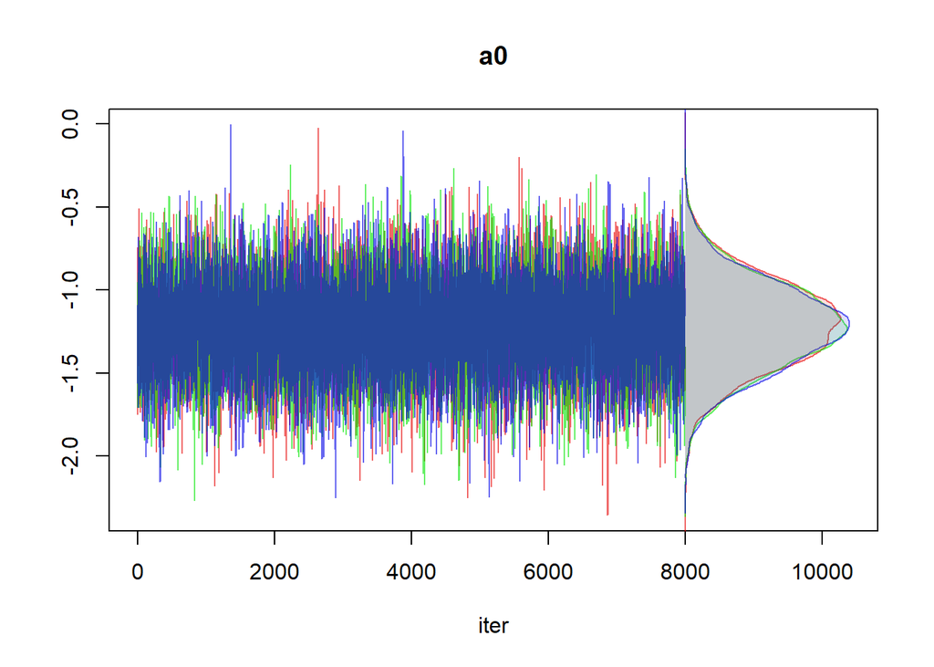

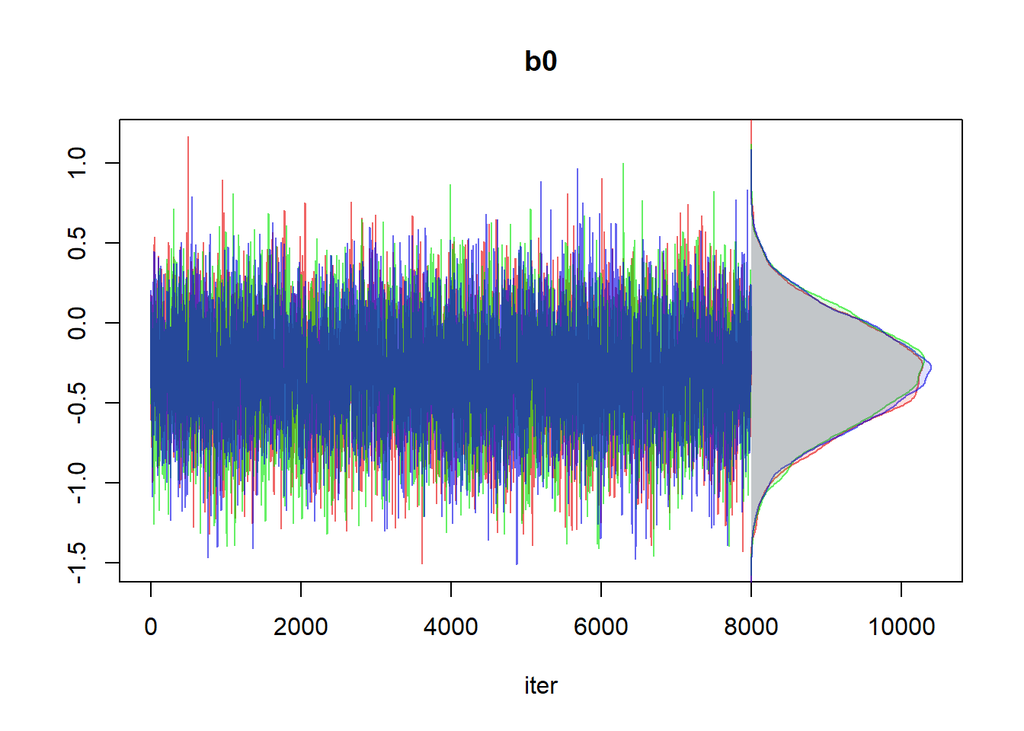

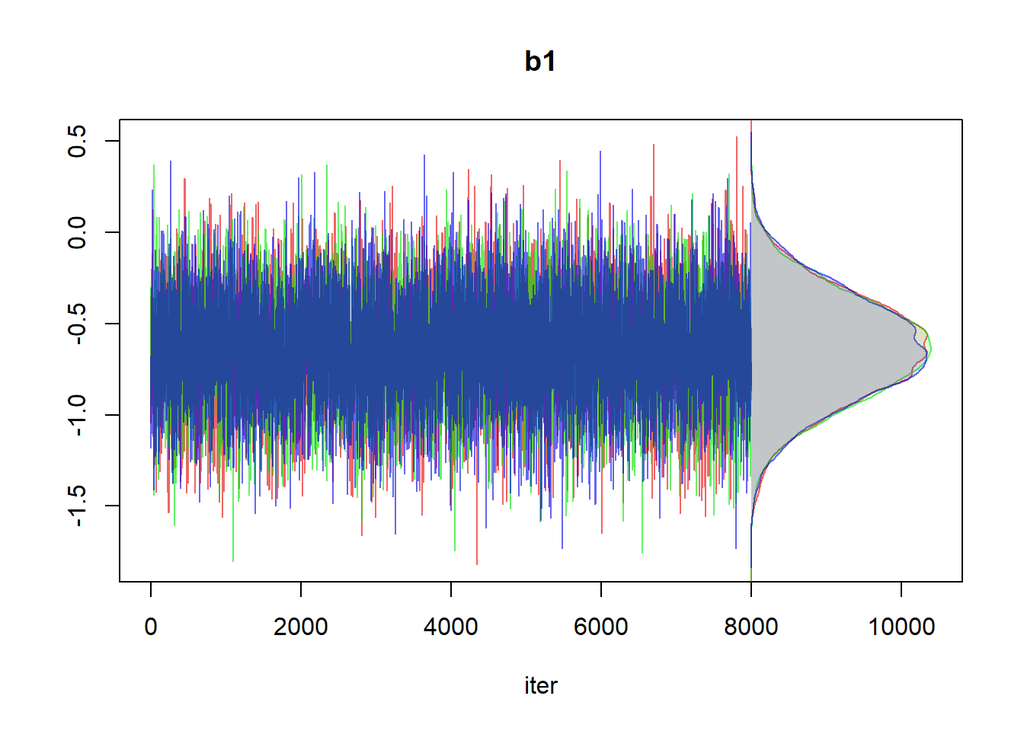

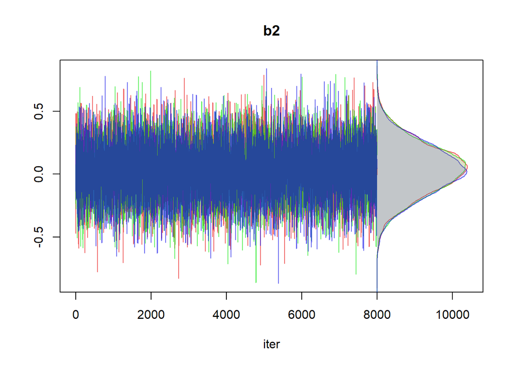

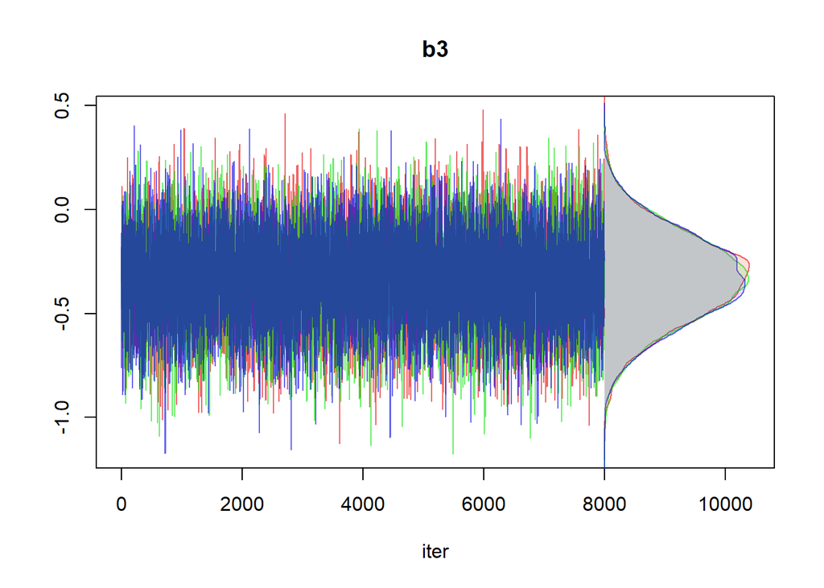

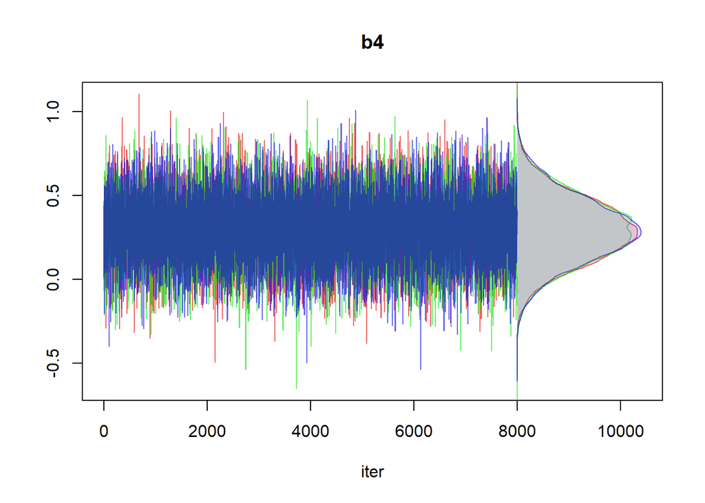

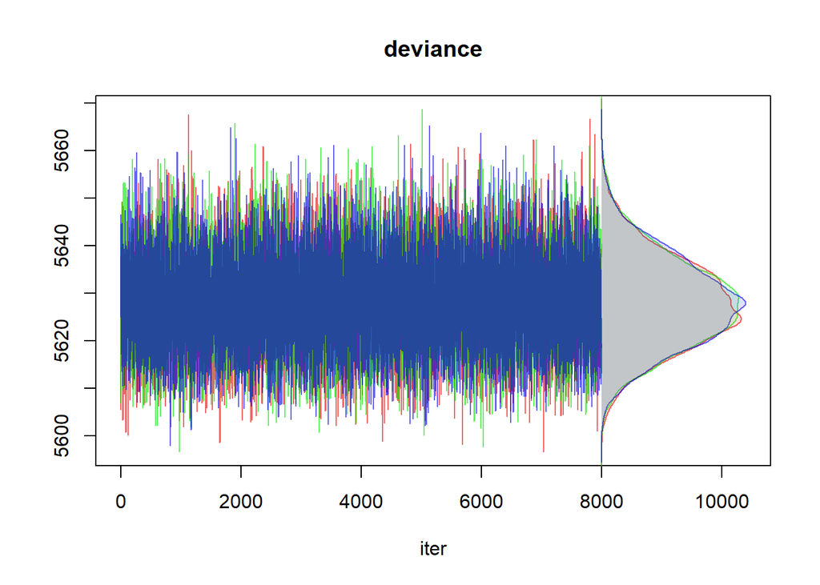

```r
tracedens_jags(habdet_m3)
```

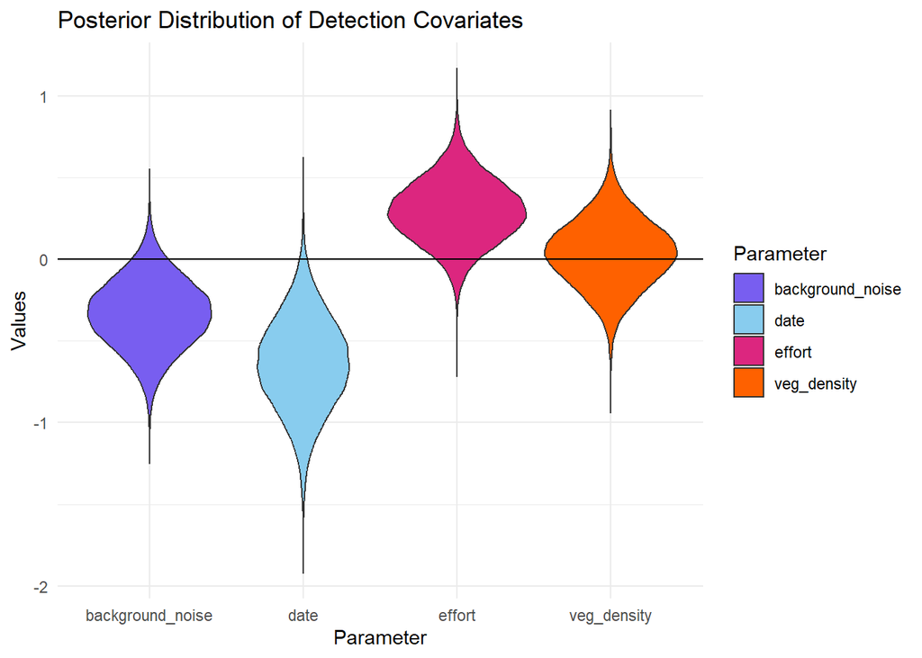

```r
# Plot posterior distribution
chains_m3 <- jags_df(habdet_m3)
# Select the chains for our covariates of interest
chains_viol3 <- chains_m3 %>% select(b1,b2,b3,b4)
# Rename them to be more interpretable
colnames(chains_viol3) <- c("date","veg_density","background_noise","effort")
# Pivot this longer so that we can visualize it
chains_viol_long3 <- chains_viol3 %>% pivot_longer(cols = c("date","veg_density","background_noise","effort"),names_to = "Parameter", values_to = "Values")

# Create the violin plot
ggplot() +
  geom_violin(data=chains_viol_long3, aes(x = Parameter, y = Values,fill = Parameter),trim = FALSE) +
  labs(title = "Posterior Distribution of Detection Covariates") +
  scale_fill_manual(values = c("date"=palette_5[1], "background_noise"=palette_5[2], "effort" = palette_5[3], "veg_density" = palette_5[4])) +
  geom_hline(yintercept = 0, linetype = "solid", color = "black") +
  theme_minimal()
```

How do I know which model fits better?